# DS in Sports, Meeting 1.

Yo

September 6, 2018

First, we install some $R$ libraries:

- $rvest$ is needed for scraping (should be installed along with $xml2$)
- $plotrix$ is needed for nice 2D map plots.

```r
library(rvest)  # Should be installed along with 'xml2'
library(plotrix) # Also install it please.
```

Below, we supply a url address with data of interest and read it via $read\_html()$ function.

```r
url_link <- 'https://www.sports-reference.com/cfb/schools/houston/2017/gamelog/'

# Read the HTML webpage for that link into an R object
url <- read_html(url_link)
```

If we look at the actual webpage corresponding to this url address, we see there’s two clear-cut data tables. The first table could be extracted from the page via the following code:

```r
# Find a 'table' on that HTML page
table_one <- xml_find_all(url, "//table")
class(table_one)
```

```
## [1] "xml_nodeset"
```

```r
# Obtain the actual contents of the table, wrapped into a data frame
table_one <- html_table(table_one)
class(table_one)
```

```
## [1] "list"
```

```r
table_one
```

```
## [[1]]
##                                                 Passing Passing Passing
## 1  Rk       Date             Opponent    Result     Cmp     Att     Pct
## 2   1 2017-09-09 @            Arizona W (19-16)      25      32    78.1
## 3   2 2017-09-16                 Rice  W (38-3)      34      38    89.5
## 4   3 2017-09-23           Texas Tech L (24-27)      32      52    61.5
## 5   4 2017-09-30 @             Temple W (20-13)      25      36    69.4
## 6   5 2017-10-07   Southern Methodist W (35-22)      20      28    71.4
## 7   6 2017-10-14 @              Tulsa L (17-45)      25      41    61.0
## 8   7 2017-10-19              Memphis L (38-42)      29      41    70.7
## 9   8 2017-10-28 @      South Florida W (28-24)      14      25    56.0
## 10  9 2017-11-04        East Carolina W (52-27)      15      22    68.2
## 11 10 2017-11-18 @             Tulane L (17-20)      18      26    69.2
## 12 11 2017-11-24                 Navy W (24-14)      21      27    77.8
## 13 12 2017-12-24 N      Fresno State* L (27-33)      23      43    53.5
```

[output cut: 46 more lines]

```r
length(table_one)
```

```
## [1] 1
```

```r
table_one[[1]]
```

```
##                                                 Passing Passing Passing
## 1  Rk       Date             Opponent    Result     Cmp     Att     Pct
## 2   1 2017-09-09 @            Arizona W (19-16)      25      32    78.1
## 3   2 2017-09-16                 Rice  W (38-3)      34      38    89.5
## 4   3 2017-09-23           Texas Tech L (24-27)      32      52    61.5
## 5   4 2017-09-30 @             Temple W (20-13)      25      36    69.4
## 6   5 2017-10-07   Southern Methodist W (35-22)      20      28    71.4
## 7   6 2017-10-14 @              Tulsa L (17-45)      25      41    61.0
## 8   7 2017-10-19              Memphis L (38-42)      29      41    70.7
## 9   8 2017-10-28 @      South Florida W (28-24)      14      25    56.0
## 10  9 2017-11-04        East Carolina W (52-27)      15      22    68.2
## 11 10 2017-11-18 @             Tulane L (17-20)      18      26    69.2
## 12 11 2017-11-24                 Navy W (24-14)      21      27    77.8
## 13 12 2017-12-24 N      Fresno State* L (27-33)      23      43    53.5
## 14      12 Games                                    281     411    68.4
```

[output cut: 45 more lines]

```r
class(table_one[[1]])
```

```
## [1] "data.frame"
```

```r
head(table_one[[1]])
```

```
##                                                Passing Passing Passing
## 1 Rk       Date             Opponent    Result     Cmp     Att     Pct
## 2  1 2017-09-09 @            Arizona W (19-16)      25      32    78.1
## 3  2 2017-09-16                 Rice  W (38-3)      34      38    89.5
## 4  3 2017-09-23           Texas Tech L (24-27)      32      52    61.5
## 5  4 2017-09-30 @             Temple W (20-13)      25      36    69.4
## 6  5 2017-10-07   Southern Methodist W (35-22)      20      28    71.4
##   Passing Passing Rushing Rushing Rushing Rushing Total Offense
## 1     Yds      TD     Att     Yds     Avg      TD         Plays
## 2     225       1      37     158     4.3       1            69
## 3     354       2      37     130     3.5       3            75
## 4     317       2      31     110     3.5       1            83
## 5     226       1      31     162     5.2       1            67
## 6     198       3      40     265     6.6       2            68
##   Total Offense Total Offense First Downs First Downs First Downs
## 1           Yds           Avg        Pass        Rush         Pen
## 2           383           5.6          11           6           1
## 3           484           6.5          16           6           0
## 4           427           5.1          14           8           3
## 5           388           5.8          10           9           4
## 6           463           6.8          10          14           3
##   First Downs Penalties Penalties Turnovers Turnovers Turnovers
## 1         Tot       No.       Yds       Fum       Int       Tot
## 2          18        10       110         0         2         2
## 3          22         2        10         0         0         0
## 4          25         6        50         3         2         5
## 5          23        12       108         0         1         1
## 6          27         4        48         0         2         2
```

Looks promising, but there’s one big issue - there were two header rows in the table, and only the first one got accounted for. Hence the second header row (‘Rk’, ‘Date’, ‘Opponent’ etc) is considered as the first *observation* rather than *column names*.

That can be fixed via hard-coding (reassigning a data frame with the first header row completely removed):

```r
tab.col.names <- table_one[[1]][1,]
table_one[[1]] <- table_one[[1]][-1,]
colnames(table_one[[1]]) <- tab.col.names
head(table_one[[1]])
```

```
##   Rk       Date             Opponent    Result Cmp Att  Pct Yds TD Att Yds
## 2  1 2017-09-09 @            Arizona W (19-16)  25  32 78.1 225  1  37 158
## 3  2 2017-09-16                 Rice  W (38-3)  34  38 89.5 354  2  37 130
## 4  3 2017-09-23           Texas Tech L (24-27)  32  52 61.5 317  2  31 110
## 5  4 2017-09-30 @             Temple W (20-13)  25  36 69.4 226  1  31 162
## 6  5 2017-10-07   Southern Methodist W (35-22)  20  28 71.4 198  3  40 265
## 7  6 2017-10-14 @              Tulsa L (17-45)  25  41 61.0 258  0  47 146
##   Avg TD Plays Yds Avg Pass Rush Pen Tot No. Yds Fum Int Tot
## 2 4.3  1    69 383 5.6   11    6   1  18  10 110   0   2   2
## 3 3.5  3    75 484 6.5   16    6   0  22   2  10   0   0   0
## 4 3.5  1    83 427 5.1   14    8   3  25   6  50   3   2   5
## 5 5.2  1    67 388 5.8   10    9   4  23  12 108   0   1   1
## 6 6.6  2    68 463 6.8   10   14   3  27   4  48   0   2   2
## 7 3.1  2    88 404 4.6   13   11   1  25   6  36   1   2   3
```

Also, we don’t quite need the LAST ROW, which is just totals for the year: we can always calculate those on our own.

```r
table_one[[1]] <- table_one[[1]][-nrow(table_one[[1]]),]
```

Let’s now take some variable summaries, e.g. average no. of completions:

```r
mean(table_one[[1]]$Cmp)
```

```
## [1] NA
```

What’s wrong? Use $summary()$ to check the types of variables in data frame resulting from $read\_html()$ operation.

```r
summary(table_one[[1]])
```

```
##       Rk                Date
##  Length:12          Length:12          Length:12
##  Class :character   Class :character   Class :character
##  Mode  :character   Mode  :character   Mode  :character
##    Opponent            Result              Cmp
##  Length:12          Length:12          Length:12
##  Class :character   Class :character   Class :character
##  Mode  :character   Mode  :character   Mode  :character
##      Att                Pct                Yds
##  Length:12          Length:12          Length:12
##  Class :character   Class :character   Class :character
##  Mode  :character   Mode  :character   Mode  :character
##       TD                Att                Yds
##  Length:12          Length:12          Length:12
##  Class :character   Class :character   Class :character
##  Mode  :character   Mode  :character   Mode  :character
##      Avg                 TD               Plays
##  Length:12          Length:12          Length:12
##  Class :character   Class :character   Class :character
##  Mode  :character   Mode  :character   Mode  :character
##      Yds                Avg                Pass
##  Length:12          Length:12          Length:12
##  Class :character   Class :character   Class :character
##  Mode  :character   Mode  :character   Mode  :character
##      Rush               Pen                Tot
##  Length:12          Length:12          Length:12
##  Class :character   Class :character   Class :character
##  Mode  :character   Mode  :character   Mode  :character
##      No.                Yds                Fum
##  Length:12          Length:12          Length:12
##  Class :character   Class :character   Class :character
##  Mode  :character   Mode  :character   Mode  :character
##      Int                Tot
##  Length:12          Length:12
##  Class :character   Class :character
##  Mode  :character   Mode  :character
```

or another way is via function $str()$

```r
str(table_one[[1]])
```

```
## 'data.frame':    12 obs. of  26 variables:
##  $ Rk      : chr  "1" "2" "3" "4" ...
##  $ Date    : chr  "2017-09-09" "2017-09-16" "2017-09-23" "2017-09-30" ...
##  $         : chr  "@" "" "" "@" ...
##  $ Opponent: chr  "Arizona" "Rice" "Texas Tech" "Temple" ...
##  $ Result  : chr  "W (19-16)" "W (38-3)" "L (24-27)" "W (20-13)" ...
##  $ Cmp     : chr  "25" "34" "32" "25" ...
##  $ Att     : chr  "32" "38" "52" "36" ...
##  $ Pct     : chr  "78.1" "89.5" "61.5" "69.4" ...
##  $ Yds     : chr  "225" "354" "317" "226" ...
##  $ TD      : chr  "1" "2" "2" "1" ...
##  $ Att     : chr  "37" "37" "31" "31" ...
##  $ Yds     : chr  "158" "130" "110" "162" ...
##  $ Avg     : chr  "4.3" "3.5" "3.5" "5.2" ...
##  $ TD      : chr  "1" "3" "1" "1" ...
##  $ Plays   : chr  "69" "75" "83" "67" ...
##  $ Yds     : chr  "383" "484" "427" "388" ...
##  $ Avg     : chr  "5.6" "6.5" "5.1" "5.8" ...
##  $ Pass    : chr  "11" "16" "14" "10" ...
##  $ Rush    : chr  "6" "6" "8" "9" ...
##  $ Pen     : chr  "1" "0" "3" "4" ...
##  $ Tot     : chr  "18" "22" "25" "23" ...
##  $ No.     : chr  "10" "2" "6" "12" ...
##  $ Yds     : chr  "110" "10" "50" "108" ...
##  $ Fum     : chr  "0" "0" "3" "0" ...
##  $ Int     : chr  "2" "0" "2" "1" ...
##  $ Tot     : chr  "2" "0" "5" "1" ...
```

All are automatically treated as characters. We’d like to convert most of those (but NOT ALL) to numeric. In particular, everything except Date, Home/Away marker, Opponent and Result. Function $as.numeric()$ comes to rescue.

```r
head(table_one[[1]])
```

```
##   Rk       Date             Opponent    Result Cmp Att  Pct Yds TD Att Yds
## 2  1 2017-09-09 @            Arizona W (19-16)  25  32 78.1 225  1  37 158
## 3  2 2017-09-16                 Rice  W (38-3)  34  38 89.5 354  2  37 130
## 4  3 2017-09-23           Texas Tech L (24-27)  32  52 61.5 317  2  31 110
## 5  4 2017-09-30 @             Temple W (20-13)  25  36 69.4 226  1  31 162
## 6  5 2017-10-07   Southern Methodist W (35-22)  20  28 71.4 198  3  40 265
## 7  6 2017-10-14 @              Tulsa L (17-45)  25  41 61.0 258  0  47 146
##   Avg TD Plays Yds Avg Pass Rush Pen Tot No. Yds Fum Int Tot
## 2 4.3  1    69 383 5.6   11    6   1  18  10 110   0   2   2
## 3 3.5  3    75 484 6.5   16    6   0  22   2  10   0   0   0
## 4 3.5  1    83 427 5.1   14    8   3  25   6  50   3   2   5
## 5 5.2  1    67 388 5.8   10    9   4  23  12 108   0   1   1
## 6 6.6  2    68 463 6.8   10   14   3  27   4  48   0   2   2
## 7 3.1  2    88 404 4.6   13   11   1  25   6  36   1   2   3
```

```r
table_one[[1]][,-c(2:5)] <- lapply(table_one[[1]][,-c(2:5)],as.numeric)

# Now verify that everything is in order:
summary(table_one[[1]])
```

```
##        Rk            Date                                Opponent
##  Min.   : 1.00   Length:12          Length:12          Length:12
##  1st Qu.: 3.75   Class :character   Class :character   Class :character
##  Median : 6.50   Mode  :character   Mode  :character   Mode  :character
##  Mean   : 6.50
##  3rd Qu.: 9.25
##  Max.   :12.00
##     Result               Cmp             Att             Pct
##  Length:12          Min.   :14.00   Min.   :22.00   Min.   :53.50
##  Class :character   1st Qu.:19.50   1st Qu.:26.75   1st Qu.:61.38
##  Mode  :character   Median :24.00   Median :34.00   Median :69.30
##                     Mean   :23.42   Mean   :34.25   Mean   :68.86
##                     3rd Qu.:26.00   3rd Qu.:41.00   3rd Qu.:73.00
##                     Max.   :34.00   Max.   :52.00   Max.   :89.50
##       Yds              TD             Att             Yds
##  Min.   :142.0   Min.   :0.000   Min.   :26.00   Min.   : 72.0
##  1st Qu.:225.0   1st Qu.:1.000   1st Qu.:31.00   1st Qu.:125.0
##  Median :263.5   Median :1.000   Median :35.00   Median :152.0
##  Mean   :261.3   Mean   :1.333   Mean   :37.17   Mean   :166.8
##  3rd Qu.:315.5   3rd Qu.:2.000   3rd Qu.:41.75   3rd Qu.:224.8
##  Max.   :354.0   Max.   :3.000   Max.   :54.00   Max.   :265.0
##       Avg              TD            Plays            Yds
##  Min.   :2.400   Min.   :1.000   Min.   :48.00   Min.   :341.0
##  1st Qu.:3.425   1st Qu.:1.000   1st Qu.:65.00   1st Qu.:386.8
##  Median :4.350   Median :2.000   Median :71.00   Median :415.5
##  Mean   :4.475   Mean   :2.083   Mean   :71.42   Mean   :428.2
##  3rd Qu.:5.350   3rd Qu.:3.000   3rd Qu.:77.00   3rd Qu.:465.2
##  Max.   :6.700   Max.   :4.000   Max.   :95.00   Max.   :554.0
##       Avg             Pass            Rush             Pen
##  Min.   :4.600   Min.   : 5.00   Min.   : 3.000   Min.   :0.000
##  1st Qu.:5.325   1st Qu.:10.00   1st Qu.: 6.000   1st Qu.:0.750
##  Median :5.800   Median :12.00   Median : 8.000   Median :1.000
##  Mean   :6.167   Mean   :11.58   Mean   : 8.083   Mean   :1.333
##  3rd Qu.:6.575   3rd Qu.:13.25   3rd Qu.: 9.500   3rd Qu.:1.500
##  Max.   :9.800   Max.   :16.00   Max.   :14.000   Max.   :4.000
##       Tot             No.            Yds              Fum
##  Min.   :16.00   Min.   : 2.0   Min.   : 10.00   Min.   :0.0000
##  1st Qu.:16.75   1st Qu.: 4.0   1st Qu.: 41.25   1st Qu.:0.0000
##  Median :22.00   Median : 5.5   Median : 45.50   Median :1.0000
##  Mean   :21.00   Mean   : 6.0   Mean   : 53.83   Mean   :0.9167
##  3rd Qu.:25.00   3rd Qu.: 6.5   3rd Qu.: 55.50   3rd Qu.:1.2500
##  Max.   :27.00   Max.   :12.0   Max.   :110.00   Max.   :3.0000
##       Int         Tot
##  Min.   :0   Min.   :0.000
##  1st Qu.:0   1st Qu.:1.000
##  Median :1   Median :2.000
##  Mean   :1   Mean   :1.917
##  3rd Qu.:2   3rd Qu.:2.250
##  Max.   :2   Max.   :5.000
```

```r
str(table_one[[1]])
```

```
## 'data.frame':    12 obs. of  26 variables:
##  $ Rk      : num  1 2 3 4 5 6 7 8 9 10 ...
##  $ Date    : chr  "2017-09-09" "2017-09-16" "2017-09-23" "2017-09-30" ...
##  $         : chr  "@" "" "" "@" ...
##  $ Opponent: chr  "Arizona" "Rice" "Texas Tech" "Temple" ...
##  $ Result  : chr  "W (19-16)" "W (38-3)" "L (24-27)" "W (20-13)" ...
##  $ Cmp     : num  25 34 32 25 20 25 29 14 15 18 ...
##  $ Att     : num  32 38 52 36 28 41 41 25 22 26 ...
##  $ Pct     : num  78.1 89.5 61.5 69.4 71.4 61 70.7 56 68.2 69.2 ...
##  $ Yds     : num  225 354 317 226 198 258 315 142 330 225 ...
##  $ TD      : num  1 2 2 1 3 0 1 1 3 0 ...
##  $ Att     : num  37 37 31 31 40 47 54 48 26 33 ...
##  $ Yds     : num  158 130 110 162 265 146 239 255 142 220 ...
##  $ Avg     : num  4.3 3.5 3.5 5.2 6.6 3.1 4.4 5.3 5.5 6.7 ...
##  $ TD      : num  1 3 1 1 2 2 4 3 3 2 ...
##  $ Plays   : num  69 75 83 67 68 88 95 73 48 59 ...
##  $ Yds     : num  383 484 427 388 463 404 554 397 472 445 ...
##  $ Avg     : num  5.6 6.5 5.1 5.8 6.8 4.6 5.8 5.4 9.8 7.5 ...
##  $ Pass    : num  11 16 14 10 10 13 16 5 8 13 ...
##  $ Rush    : num  6 6 8 9 14 11 9 11 7 8 ...
##  $ Pen     : num  1 0 3 4 3 1 0 0 1 1 ...
##  $ Tot     : num  18 22 25 23 27 25 25 16 16 22 ...
##  $ No.     : num  10 2 6 12 4 6 8 5 4 5 ...
##  $ Yds     : num  110 10 50 108 48 36 72 45 34 46 ...
##  $ Fum     : num  0 0 3 0 0 1 2 1 0 1 ...
##  $ Int     : num  2 0 2 1 2 2 1 0 0 1 ...
##  $ Tot     : num  2 0 5 1 2 3 3 1 0 2 ...
```

Next, we could play around with pairwise scatterplots for variables in the data set. Make sure to only consider *numerical* variables (no factors or characters).

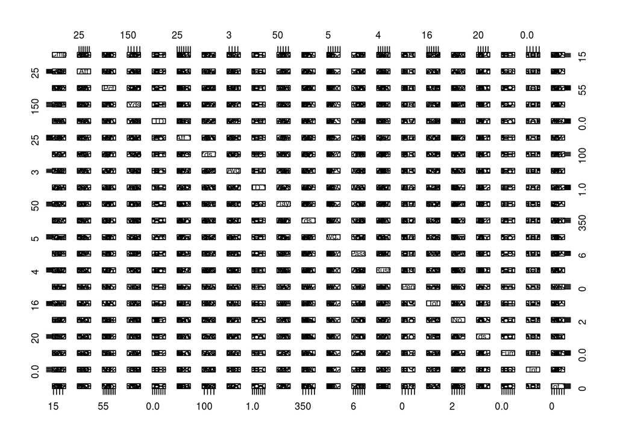

```r
#pairs(table_one[[1]]) # Error - get rid of non-numerical stuff

pairs(table_one[[1]][,-c(1:5)])  # A bit problematic to read, isn't it?
```

A bit problematic to read, isn’t it? Let’s scale down and just look at **subsets of variables**:

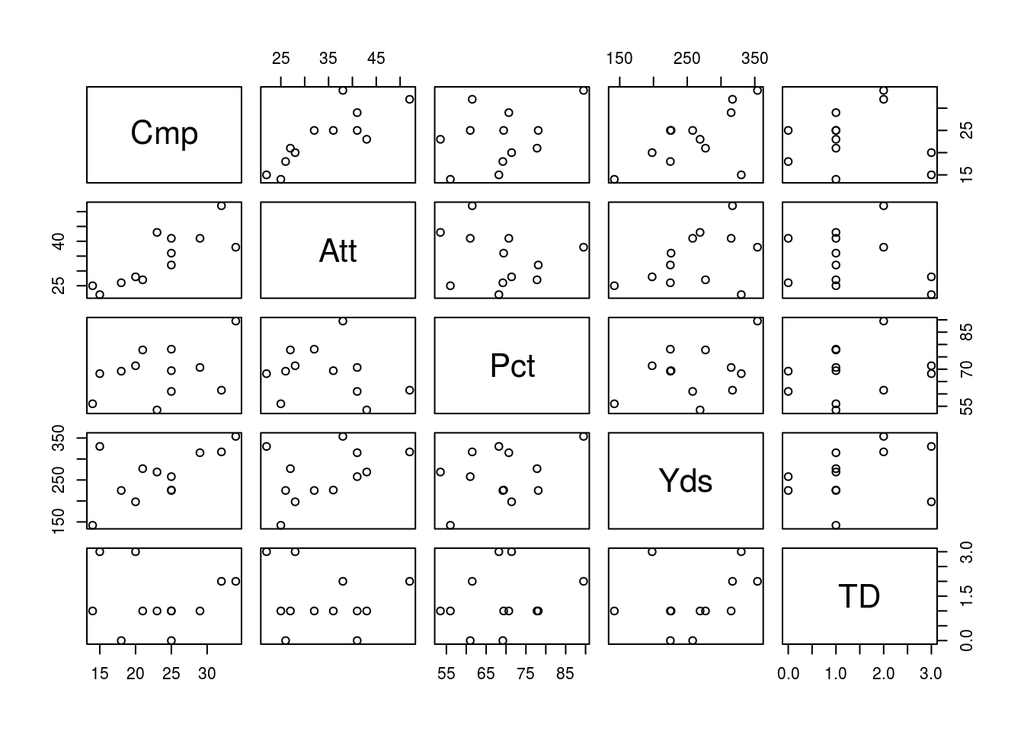

```r
# Let's just look at subsets of variables
pairs(table_one[[1]][,c(6:10)])
```

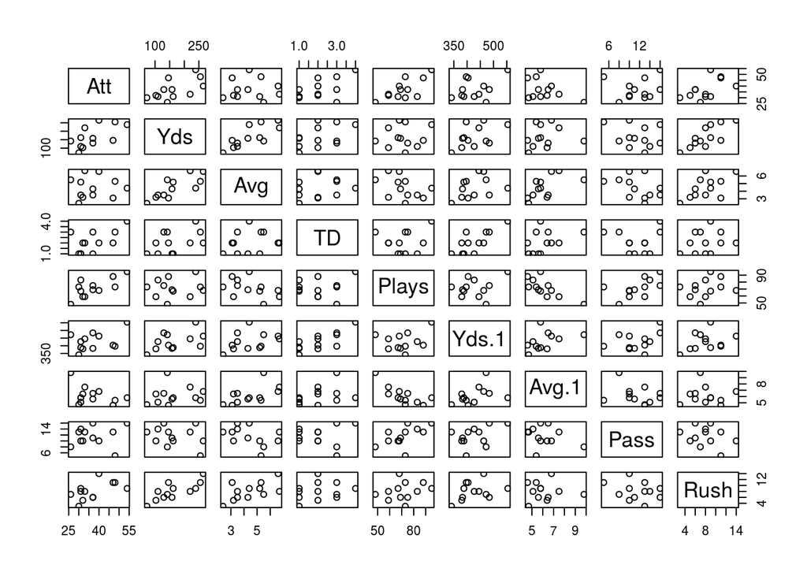

```r
pairs(table_one[[1]][,c(11:19)])
```

In all honesty, there’s not too much you can ever see from 12 data points. Hence we proceed to obtaining data on more college football teams.

## Getting data on more teams.

Let’s get tables on several teams, to obtain a larger sample of games. For that, first we need to specify the url-versions of team names we’re interested in. For the time being, let’s just limit ourselves to UH, Rice, Texas Tech, Temple & Tulsa.

```r
team_names <- c('houston', 'rice', 'texas-tech','temple','tulsa')
```

Next, we need to code up a method to automatically create a full URL for each team name. It is done via $paste()$ function. E.g., how can we get the name

“https://www.sports-reference.com/cfb/schools/houston/2017/gamelog/”

via $paste()$ function and the team name *‘houston’*?

```r
url_link <- paste('https://www.sports-reference.com/cfb/schools/',team_names[1],'/2017/gamelog/')
url_link
```

```
## [1] "https://www.sports-reference.com/cfb/schools/ houston /2017/gamelog/"
```

Issue here? There are white spaces at string connection points. Use **‘sep=’ option** to get rid of those.

```r
url_link <- paste('https://www.sports-reference.com/cfb/schools/',team_names[1],'/2017/gamelog/',
                  sep="")
url_link
```

```
## [1] "https://www.sports-reference.com/cfb/schools/houston/2017/gamelog/"
```

From now on, in order to obtain data on UH, we could simply apply all of the aforementioned code to this calculated url.

Now, how do we automatically loop through all the team names? Easy:

Loop through indices (i=1,…,5), where for each i we:

1. Calculate the url for $team\_names[i]$.
2. Extract the table.

We’ll keep all the tables in one big data frame object $offense\_data$, and also replace the useless first column (‘Rk’) with a team name column:

```r
offense_data <- NULL
team_names <- c('houston', 'rice', 'texas-tech','temple','tulsa')

for (i in 1:length(team_names)){
  url_link <- paste('https://www.sports-reference.com/cfb/schools/',team_names[i],'/2017/gamelog/',
                    sep="")
  url <- read_html(url_link)
  table_one <- xml_find_all(url, "//table")
  table_one <- html_table(table_one)[[1]]

  tab.col.names <- table_one[1,]
  table_one <- table_one[-1,]
  colnames(table_one) <- tab.col.names

  table_one <- table_one[-nrow(table_one),]
  table_one[,-c(2:5)] <- lapply(table_one[,-c(2:5)],as.numeric)
  table_one[,1] <- team_names[i]
  colnames(table_one)[1] <- "Team"

  print(head(table_one,2)) # Print out the header from extracted table for the team.
  cat("\n")
  offense_data <- rbind(offense_data, table_one)
}
```

```
##      Team       Date   Opponent    Result Cmp Att  Pct Yds TD Att Yds Avg
## 2 houston 2017-09-09 @  Arizona W (19-16)  25  32 78.1 225  1  37 158 4.3
## 3 houston 2017-09-16       Rice  W (38-3)  34  38 89.5 354  2  37 130 3.5
##   TD Plays Yds Avg Pass Rush Pen Tot No. Yds Fum Int Tot
## 2  1    69 383 5.6   11    6   1  18  10 110   0   2   2
## 3  3    75 484 6.5   16    6   0  22   2  10   0   0   0
##
##   Team       Date        Opponent    Result Cmp Att  Pct Yds TD Att Yds
## 2 rice 2017-08-26 N      Stanford  L (7-62)  10  24 41.7  95  0  38 146
## 3 rice 2017-09-09 @ Texas-El Paso W (31-14)  10  18 55.6 131  1  49 306
##   Avg TD Plays Yds Avg Pass Rush Pen Tot No. Yds Fum Int Tot
## 2 3.8  1    62 241 3.9    5    8   1  14   6  45   1   1   2
## 3 6.2  3    67 437 6.5    6   16   0  22   4  31   1   0   1
##
##         Team       Date            Opponent    Result Cmp Att  Pct Yds TD
## 2 texas-tech 2017-09-02  Eastern Washington W (56-10)  31  35 88.6 449  4
## 3 texas-tech 2017-09-16       Arizona State W (52-45)  37  50 74.0 543  6
##   Att Yds Avg TD Plays Yds Avg Pass Rush Pen Tot No. Yds Fum Int Tot
## 2  40 177 4.4  3    75 626 8.3   17   12   3  32  11 120   0   0   0
## 3  29  72 2.5  1    79 615 7.8   27    5   1  33   6  67   1   0   1
##
##     Team       Date     Opponent    Result Cmp Att  Pct Yds TD Att Yds Avg
## 2 temple 2017-09-02 @ Notre Dame L (16-49)  19  35 54.3 245  2  37  85 2.3
## 3 temple 2017-09-09    Villanova W (16-13)  20  34 58.8 274  0  27  79 2.9
##   TD Plays Yds Avg Pass Rush Pen Tot No. Yds Fum Int Tot
## 2  0    72 330 4.6   13    4   1  18   6  42   1   0   1
## 3  1    61 353 5.8   10    5   2  17   8  59   0   0   0
##
##    Team       Date         Opponent    Result Cmp Att  Pct Yds TD Att Yds
## 2 tulsa 2017-08-31 @ Oklahoma State L (24-59)  20  38 52.6 188  0  60 244
## 3 tulsa 2017-09-09        Louisiana W (66-42)  14  20 70.0 243  1  72 424
##   Avg TD Plays Yds Avg Pass Rush Pen Tot No. Yds Fum Int Tot
## 2 4.1  2    98 432 4.4   10   14   2  26   6  48   2   0   2
## 3 5.9  8    92 667 7.3    9   21   3  33   5  46   1   0   1
```

```r
dim(offense_data)
```

```
## [1] 62 26
```

```r
head(offense_data)
```

```
##      Team       Date             Opponent    Result Cmp Att  Pct Yds TD
## 2 houston 2017-09-09 @            Arizona W (19-16)  25  32 78.1 225  1
## 3 houston 2017-09-16                 Rice  W (38-3)  34  38 89.5 354  2
## 4 houston 2017-09-23           Texas Tech L (24-27)  32  52 61.5 317  2
## 5 houston 2017-09-30 @             Temple W (20-13)  25  36 69.4 226  1
## 6 houston 2017-10-07   Southern Methodist W (35-22)  20  28 71.4 198  3
## 7 houston 2017-10-14 @              Tulsa L (17-45)  25  41 61.0 258  0
##   Att Yds Avg TD Plays Yds Avg Pass Rush Pen Tot No. Yds Fum Int Tot
## 2  37 158 4.3  1    69 383 5.6   11    6   1  18  10 110   0   2   2
## 3  37 130 3.5  3    75 484 6.5   16    6   0  22   2  10   0   0   0
## 4  31 110 3.5  1    83 427 5.1   14    8   3  25   6  50   3   2   5
## 5  31 162 5.2  1    67 388 5.8   10    9   4  23  12 108   0   1   1
## 6  40 265 6.6  2    68 463 6.8   10   14   3  27   4  48   0   2   2
## 7  47 146 3.1  2    88 404 4.6   13   11   1  25   6  36   1   2   3
```

Before proceeding, let’s save our scraped offensive logs into a file $Scraped\_Offense.txt$.

```r
write.table(offense_data,"Scraped_Offense.txt")
```

Now that we have combined data for five teams, resulting into a total of roughly 60 observations, let’s get pairwise scatterplots for different variables

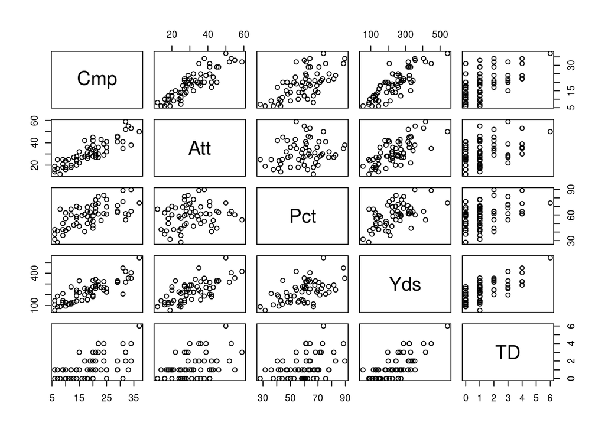

```r
pairs(offense_data[,c(6:10)])
```

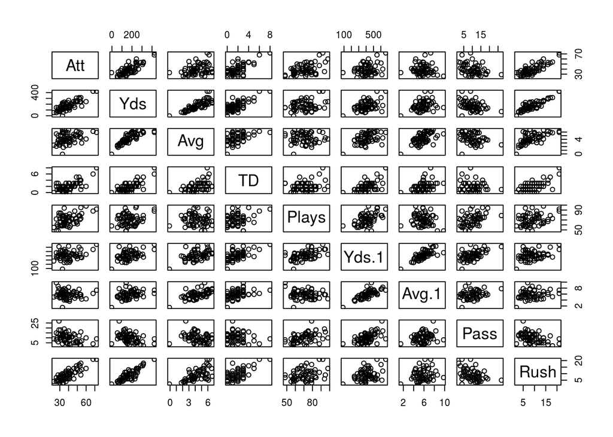

```r
pairs(offense_data[,c(11:19)])
```

Pretty clogged up and tough to interpret. To substitute these messy plots for a nice numerical summary, let’s calculate all pairwise *correlations* via $cor()$ function applied to all numeric variables.

```r
## Get correlation matrix.
offense_data_num <- offense_data[,-c(1:5)]
cor(offense_data_num)  # Tough to read.
```

```
##               Cmp         Att          Pct         Yds          TD
## Cmp    1.00000000  0.87001974  0.634844554  0.82773082  0.53342036
## Att    0.87001974  1.00000000  0.196898125  0.70786326  0.41460928
## Pct    0.63484455  0.19689813  1.000000000  0.54573762  0.39906706
## Yds    0.82773082  0.70786326  0.545737623  1.00000000  0.72577827
## TD     0.53342036  0.41460928  0.399067059  0.72577827  1.00000000
## Att.1 -0.36412029 -0.40693776 -0.094698880 -0.37602372 -0.32127498
## Yds.1 -0.36772899 -0.48314262  0.039582034 -0.33922514 -0.15865152
## Avg   -0.23895858 -0.38226336  0.152112357 -0.19093818  0.02250173
## TD.1  -0.12090937 -0.35063460  0.339625617 -0.01267863 -0.14511803
## Plays  0.50184341  0.58708251  0.102679965  0.33761525  0.10821202
## Yds.2  0.48144219  0.27781966  0.541326436  0.66502855  0.55216905
## Avg.1  0.17779118 -0.10846734  0.539322743  0.51002229  0.52836239
## Pass   0.90625711  0.79594840  0.562443627  0.89119847  0.61884854
## Rush  -0.35889326 -0.43482252 -0.044802166 -0.35960008 -0.18736797
## Pen    0.06123887  0.08766964  0.003629749  0.05684918  0.01795532
## Tot    0.51623293  0.36734980  0.452574550  0.50148273  0.39206683
## No.    0.32818008  0.40098183  0.029694221  0.29088858  0.20284983
## Yds.3  0.36176677  0.38034374  0.119780752  0.33236144  0.33645280
## Fum   -0.09311270 -0.04317466 -0.166412339 -0.17436073 -0.19596964
## Int   -0.15218146  0.13183343 -0.513352779 -0.18082766 -0.09041127
## Tot.1 -0.16554363  0.06329769 -0.462889367 -0.23792651 -0.18933805
##             Att.1        Yds.1         Avg        TD.1       Plays
## Cmp   -0.36412029 -0.367728989 -0.23895858 -0.12090937  0.50184341
## Att   -0.40693776 -0.483142618 -0.38226336 -0.35063460  0.58708251
## Pct   -0.09469888  0.039582034  0.15211236  0.33962562  0.10267996
## Yds   -0.37602372 -0.339225135 -0.19093818 -0.01267863  0.33761525
## TD    -0.32127498 -0.158651518  0.02250173 -0.14511803  0.10821202
## Att.1  1.00000000  0.805139731  0.34007820  0.67231523  0.50056125
## Yds.1  0.80513973  1.000000000  0.81259663  0.72250072  0.25565036
## Avg    0.34007820  0.812596634  1.00000000  0.46228536 -0.06089326
## TD.1   0.67231523  0.722500717  0.46228536  1.00000000  0.26351862
## Plays  0.50056125  0.255650357 -0.06089326  0.26351862  1.00000000
## Yds.2  0.28786095  0.476941127  0.46671310  0.56174111  0.51840492
## Avg.1 -0.05966019  0.342273169  0.59604142  0.43437344 -0.15566908
## Pass  -0.35873960 -0.385215045 -0.27194468 -0.11678205  0.43641297
## Rush   0.81729445  0.876476166  0.59983260  0.65879631  0.31221613
## Pen    0.16095214  0.146262377  0.02827033  0.14898763  0.22572609
## Tot    0.37969364  0.399877666  0.24770710  0.46040151  0.68463889
## No.   -0.13267110 -0.061026831  0.04895481 -0.10621048  0.26244242
```

[output cut: 55 more lines]

```
## Yds.1 -0.13988070
## Avg   -0.15197732
## TD.1  -0.30751993
## Plays -0.01372329
## Yds.2 -0.33335354
## Avg.1 -0.37340391
## Pass  -0.18802336
## Rush  -0.01036821
## Pen   -0.25440490
## Tot   -0.23750955
## No.   -0.22402699
## Yds.3 -0.20079934
## Fum    0.72625252
## Int    0.76616781
## Tot.1  1.00000000
```

The matrix in itself is pretty bulky, but we could *plot* it with the help of *$plotrix$ package* and its function $color2D.matplot()$. Don’t get too preoccupied with the $cs1-cs3$ arguments - they control the color scheme of the plot, and I’ve simply set them to take on darker color for larger correlation values.

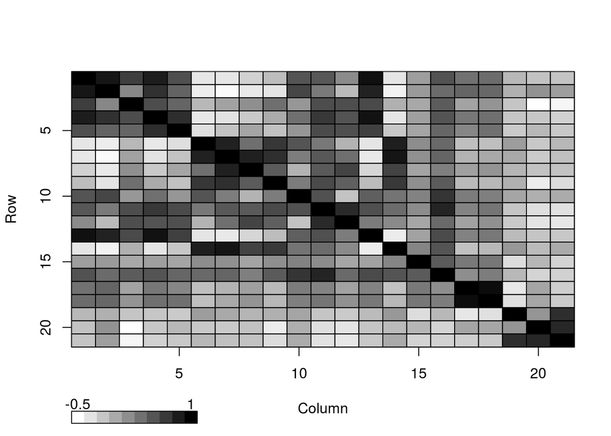

```r
library(plotrix)
color2D.matplot(cor(offense_data_num),
                cs1=c(1,0),cs2=c(1,0),cs3=c(1,0),
                show.legend=T)
```

Issue with this plot is that we are not really interested in sign of correlation (whether it’s positive or negative). Knowing the strength of correlation would do it for us. Apply $abs()$ function.

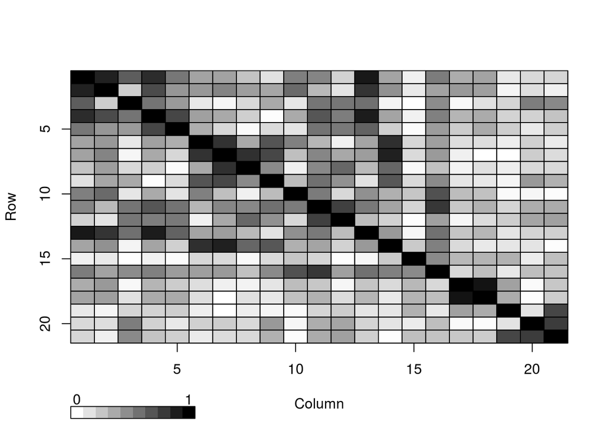

```r
color2D.matplot(abs(cor(offense_data_num)),
                cs1=c(1,0),cs2=c(1,0),cs3=c(1,0),
                show.legend=T)
```

Cleaner, but still a bit dirty. We could *threshold* values, so that all correlations less than the thresholds are SET TO 0. This may be done via $ifelse()$. Below I set to zero all the correlations that are below 0.8 in absolute value.

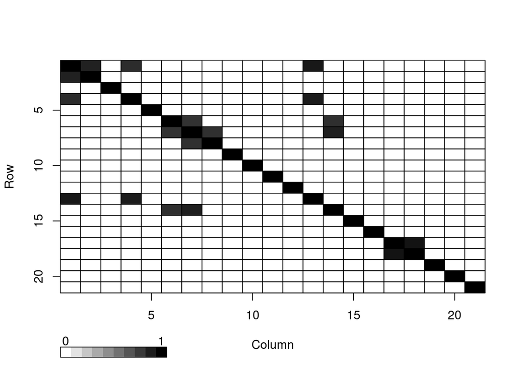

```r
abs.cor.mat <- abs(cor(offense_data_num))
color2D.matplot(ifelse(abs.cor.mat>=0.8, abs.cor.mat,0),
                cs1=c(1,0),cs2=c(1,0),cs3=c(1,0),
                show.legend=T)
```

```r
colnames(abs.cor.mat)  # To know which row/column corresponds to which variable.
```

```
##  [1] "Cmp"   "Att"   "Pct"   "Yds"   "TD"    "Att.1" "Yds.1" "Avg"
##  [9] "TD.1"  "Plays" "Yds.2" "Avg.1" "Pass"  "Rush"  "Pen"   "Tot"
## [17] "No."   "Yds.3" "Fum"   "Int"   "Tot.1"
```

To pretty up the plot and make it much more informative, we could take numerous steps. One of them - making the variable names show up along rows and columns. Functions $axis()$ and $par()$ (with its $las$ option that dictates whether text is printed vertically or horizontally) help us with that.

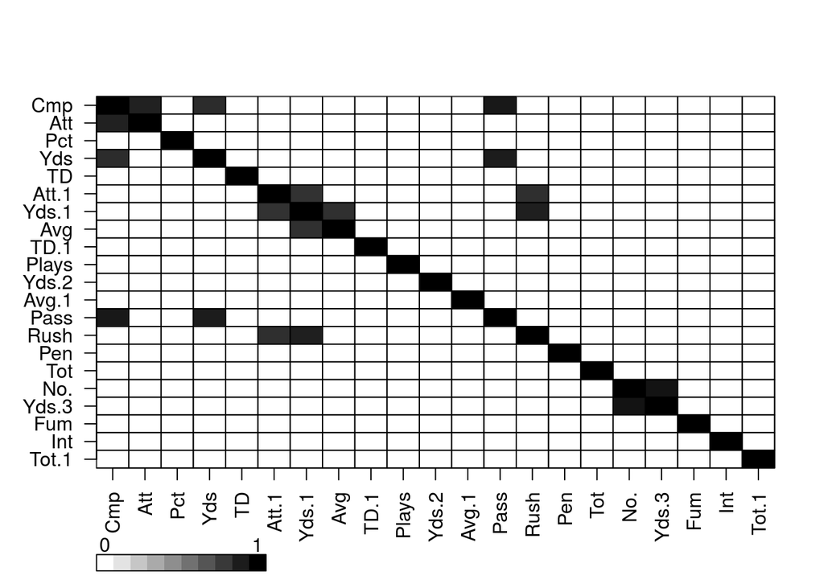

```r
color2D.matplot(ifelse(abs.cor.mat>=0.8, abs.cor.mat,0),
                cs1=c(1,0),cs2=c(1,0),cs3=c(1,0),
                show.legend = T,
                xlab='',
                ylab='',
                axes=F)
par(las=2)
axis(1,at=c(1:ncol(abs.cor.mat))-0.5,labels=colnames(abs.cor.mat))
par(las=1)
axis(2,at=c(ncol(abs.cor.mat):1)-0.5,labels=colnames(abs.cor.mat))
```